# daily assighnemt 27 and 28

First, I used the code from lecture to extract all the waterways from OpenStreetMap for the Bounding Box of Fort Collins, CO.

```r
library(sf)
library(osmdata)
library(terra)
fc <- AOI::geocode("Fort Collins", bbox = TRUE)

foco_rivers <- opq(bbox = st_bbox(fc)) |>
  add_osm_feature(key = "waterway") |>
  osmdata_sf()

foco_rivers_lines <- foco_rivers$osm_lines
```

```r
library(dplyr)
poudre <- foco_rivers$osm_lines |>
  filter(grepl("Cache la Poudre", name, ignore.case = TRUE))

poudre_merged <- st_union(poudre)

poudre_merged_sf <- st_as_sf(data.frame(geometry = poudre_merged), crs = st_crs(poudre))
```

I used the code above to Filter the osm_lines object to only include the Cache la Poudre River and merge the lines into a single line object with st_union(). Then, I converted the object to a sf object witt st_as_sf()

```r
poudre_length <- st_length(poudre_merged_sf)
print(poudre_length)
```

```
218200.2 [m]
```

I used the code above to compute the length of the river for future calculations.

```r
poudre_pts <- st_cast(poudre_merged_sf, "POINT")
```

I used the code above to convert the river object to a POINT object and save it as poudre_pts for later extraction tasks.

Define DEM object

```r
library(terra)
Sys.setenv("AWS_NO_SIGN_REQUEST" = "YES")

elevation = rast('/vsis3/lynker-spatial/gridded-resources/dem.vrt')

print(elevation)
```

```
class       : SpatRaster
dimensions  : 114503, 163008, 1  (nrow, ncol, nlyr)
resolution  : 30, 30  (x, y)
extent      : -2470965, 2419275, 186285, 3621375  (xmin, xmax, ymin, ymax)
coord. ref. : +proj=aea +lat_0=23 +lon_0=-96 +lat_1=29.5 +lat_2=45.5 +x_0=0 +y_0=0 +datum=NAD83 +units=m +no_defs
source      : dem.vrt
name        : dem
```

I used the code above to read in the DEM file from the lynker-spatial S3 bucket shared in the last assighnment

Extract River Profile

```r
poudre_pts_utm <- st_transform(poudre_pts, crs = crs(elevation))
poudre_utm <- st_transform(poudre_merged_sf, crs = 26913)

poudre_vect <- vect(poudre_pts_utm)

elev_values <- terra::extract(elevation, poudre_vect)
```

I used the code above to extract the elevation values from the DEM at the point along the river

```r
poudre_pts_elevation <- bind_cols(poudre_pts_utm, elevation = elev_values[[2]])
```

I used the code above to combine the spatial river points with the extracted elevation values

```r
poudre_pts_elevation <- poudre_pts_elevation |>
  mutate(ID = 1:n())

head(poudre_pts_elevation)
```

```
Simple feature collection with 6 features and 2 fields
Geometry type: POINT
Dimension:     XY
Bounding box:  xmin: -758330.8 ymin: 1987730 xmax: -758188.1 ymax: 1988082
Projected CRS: unnamed
  elevation                  geometry ID
1    150035 POINT (-758310.8 1987730)  1
2    150017 POINT (-758330.8 1987757)  2
3    150050 POINT (-758302.2 1987882)  3
4    150050   POINT (-758253 1988019)  4
5    150058 POINT (-758236.7 1988052)  5
6    150050 POINT (-758188.1 1988082)  6
```

I used the code above to add a new column called ID that is a sequence from 1 to the number of points on the river (n()).

Compute Sinuosity

```r
first_point <- st_geometry(poudre_pts_elevation)[1]
last_point <- st_geometry(poudre_pts_elevation)[nrow(poudre_pts_elevation)]

straight_line_distance <- st_distance(first_point, last_point)
```

I used the code above to compute the straight line distance between the first and last points in the river

```r
total_length <- st_length(poudre_utm)

sinuosity <- total_length / straight_line_distance

print(sinuosity)
```

```
Units: [1]
         [,1]
[1,] 17.07305
```

Compute Slope

```r
elev_first <- elev_values[1, 2]
elev_last <- elev_values[nrow(elev_values), 2]

elevation_change <- elev_last - elev_first

total_length_cm <- total_length * 100

slope <- elevation_change / total_length_cm
print(slope)
```

```
0.0002712977 [1/m]
```

Map Profile: 2 ways

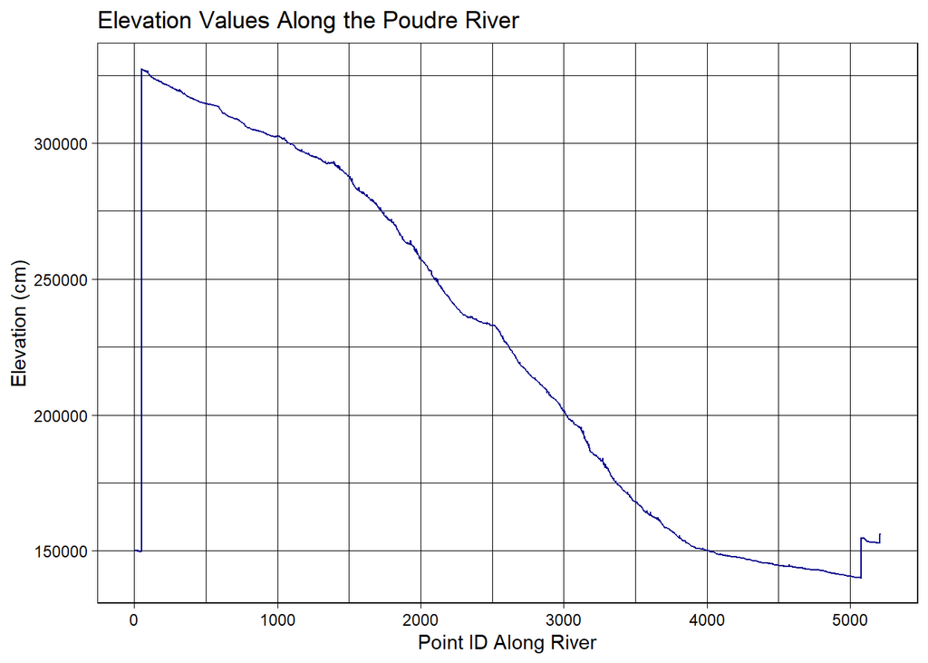

```r
library(ggplot2)

ggplot(poudre_pts_elevation) +
  aes(x = ID, y = elevation) +
  geom_line(color = "darkblue") +
  labs(
    title = "Elevation Values Along the Poudre River",
    x = "Point ID Along River",
    y = "Elevation (cm)"
  ) +
  theme_linedraw()
```

I used the code above to create a line plot of the elevation values along the river.

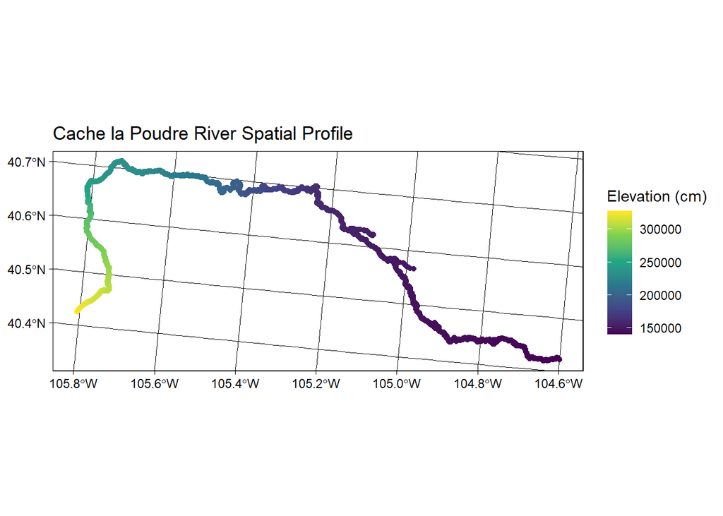

```r
poudre_sf <- st_as_sf(poudre_pts_elevation)

ggplot(poudre_sf) +
  geom_sf(aes(color = elevation)) +
  scale_color_viridis_c(option = "viridis", name = "Elevation (cm)") +
  labs(title = "Cache la Poudre River Spatial Profile") +
  theme_linedraw()
```

I used the code above to plot the spatial map of the river profile.